# LBB

Dwi Retno Fibriyanti

2022-06-02

# Tentang dataset

Berikut ini adalah keterangan datanya :

1. `id`: id pasien
2. `gender`: “Pria”, “Wanita” atau “Lainnya”
3. `age`: usia pasien
4. `hypertension`: 0 jika pasien tidak memiliki hipertensi, 1 jika pasien memiliki hipertensi
5. `heart_disease`: 0 jika pasien tidak memiliki penyakit jantung, 1 jika pasien memiliki penyakit jantung
6. `ever_married`: “Tidak” atau “Ya”
7. `work_type`: “anak-anak”, “Govt_jov”, “Tidak pernah_bekerja”, “Swasta” atau “Wiraswasta”
8. `Residence_type`: “Pedesaan” atau “Perkotaan”
9. `avg_glucose_level`: tingkat glukosa rata-rata dalam darah
10. `bmi`: indeks massa tubuh
11. `smoking_status`: “sebelumnya merokok”, “tidak pernah merokok”, “merokok” atau “Tidak diketahui”*
12. `stroke`: 1 jika pasien mengalami stroke atau 0 jika tidak

# Load Library

```r
library(dplyr)
library(e1071)
library(caret)
library(rsample)
library(randomForest)
```

# Read Data

```r
stroke <- read.csv("data_input/healthcare-dataset-stroke-data.csv")
head(stroke)
```

|  | id | gender | age | hypertension | heart_disease | ever_married | work_type | Residence_type | avg_glucose_level | bmi | smoking_status | stroke |
| --- | --- | --- | --- | --- | --- | --- | --- | --- | --- | --- | --- | --- |
| 1 | 9046 | Male | 67 | 0 | 1 | Yes | Private | Urban | 228.69 | 36.6 | formerly smoked | 1 |
| 2 | 51676 | Female | 61 | 0 | 0 | Yes | Self-employed | Rural | 202.21 | N/A | never smoked | 1 |
| 3 | 31112 | Male | 80 | 0 | 1 | Yes | Private | Rural | 105.92 | 32.5 | never smoked | 1 |
| 4 | 60182 | Female | 49 | 0 | 0 | Yes | Private | Urban | 171.23 | 34.4 | smokes | 1 |
| 5 | 1665 | Female | 79 | 1 | 0 | Yes | Self-employed | Rural | 174.12 | 24 | never smoked | 1 |
| 6 | 56669 | Male | 81 | 0 | 0 | Yes | Private | Urban | 186.21 | 29 | formerly smoked | 1 |

Karena disini saya tidak menggunakan `id` sebagai data untuk dianalisis, maka akan saya buang kolom tersebut.Dan variabel yang ada pada data `stroke` diubah menjadi `factor` dan di pipping dengan nama `stroke_clean`.

```r
dim(stroke)
```

```
## [1] 5110   12
```

```r
glimpse(stroke)
```

```
## Rows: 5,110
## Columns: 12
## $ id                <int> 9046, 51676, 31112, 60182, 1665, 56669, 53882, 10434~
## $ gender            <chr> "Male", "Female", "Male", "Female", "Female", "Male"~
## $ age               <dbl> 67, 61, 80, 49, 79, 81, 74, 69, 59, 78, 81, 61, 54, ~
## $ hypertension      <int> 0, 0, 0, 0, 1, 0, 1, 0, 0, 0, 1, 0, 0, 0, 0, 1, 0, 1~
## $ heart_disease     <int> 1, 0, 1, 0, 0, 0, 1, 0, 0, 0, 0, 1, 0, 1, 1, 0, 1, 0~
## $ ever_married      <chr> "Yes", "Yes", "Yes", "Yes", "Yes", "Yes", "Yes", "No~
## $ work_type         <chr> "Private", "Self-employed", "Private", "Private", "S~
## $ Residence_type    <chr> "Urban", "Rural", "Rural", "Urban", "Rural", "Urban"~
## $ avg_glucose_level <dbl> 228.69, 202.21, 105.92, 171.23, 174.12, 186.21, 70.0~
## $ bmi               <chr> "36.6", "N/A", "32.5", "34.4", "24", "29", "27.4", "~
## $ smoking_status    <chr> "formerly smoked", "never smoked", "never smoked", "~
## $ stroke            <int> 1, 1, 1, 1, 1, 1, 1, 1, 1, 1, 1, 1, 1, 1, 1, 1, 1, 1~
```

```r
stroke %>% filter(bmi == "N/A")
```

| id | gender | age | hypertension | heart_disease | ever_married | work_type | Residence_type | avg_glucose_level | bmi | smoking_status | stroke |
| --- | --- | --- | --- | --- | --- | --- | --- | --- | --- | --- | --- |
| 51676 | Female | 61.00 | 0 | 0 | Yes | Self-employed | Rural | 202.21 | N/A | never smoked | 1 |
| 27419 | Female | 59.00 | 0 | 0 | Yes | Private | Rural | 76.15 | N/A | Unknown | 1 |
| 8213 | Male | 78.00 | 0 | 1 | Yes | Private | Urban | 219.84 | N/A | Unknown | 1 |
| 25226 | Male | 57.00 | 0 | 1 | No | Govt_job | Urban | 217.08 | N/A | Unknown | 1 |
| 61843 | Male | 58.00 | 0 | 0 | Yes | Private | Rural | 189.84 | N/A | Unknown | 1 |
| 69160 | Male | 59.00 | 0 | 0 | Yes | Private | Rural | 211.78 | N/A | formerly smoked | 1 |
| 1845 | Female | 63.00 | 0 | 0 | Yes | Private | Urban | 90.90 | N/A | formerly smoked | 1 |
| 37937 | Female | 75.00 | 0 | 1 | No | Self-employed | Urban | 109.78 | N/A | Unknown | 1 |
| 18587 | Female | 76.00 | 0 | 0 | No | Private | Urban | 89.96 | N/A | Unknown | 1 |
| 15102 | Male | 78.00 | 1 | 0 | Yes | Private | Urban | 75.32 | N/A | formerly smoked | 1 |

[output cut: 191 more lines]

```r
stroke_clean <- stroke %>% filter(bmi != "N/A") %>%
  select(-id) %>%
  mutate(bmi = as.numeric(bmi),
         stroke = as.factor(stroke)) %>%
  mutate_at(vars(hypertension, heart_disease),as.factor) %>%
  # gender, ever_married, work_type, residence_type, smoking_status
  mutate_if(is.character, as.factor)

glimpse(stroke_clean)
```

```
## Rows: 4,909
## Columns: 11
## $ gender            <fct> Male, Male, Female, Female, Male, Male, Female, Fema~
## $ age               <dbl> 67, 80, 49, 79, 81, 74, 69, 78, 81, 61, 54, 79, 50, ~
## $ hypertension      <fct> 0, 0, 0, 1, 0, 1, 0, 0, 1, 0, 0, 0, 1, 0, 1, 0, 0, 1~
## $ heart_disease     <fct> 1, 1, 0, 0, 0, 1, 0, 0, 0, 1, 0, 1, 0, 1, 0, 0, 0, 0~
## $ ever_married      <fct> Yes, Yes, Yes, Yes, Yes, Yes, No, Yes, Yes, Yes, Yes~
## $ work_type         <fct> Private, Private, Private, Self-employed, Private, P~
## $ Residence_type    <fct> Urban, Rural, Urban, Rural, Urban, Rural, Urban, Urb~
## $ avg_glucose_level <dbl> 228.69, 105.92, 171.23, 174.12, 186.21, 70.09, 94.39~
## $ bmi               <dbl> 36.6, 32.5, 34.4, 24.0, 29.0, 27.4, 22.8, 24.2, 29.7~
## $ smoking_status    <fct> formerly smoked, never smoked, smokes, never smoked,~
## $ stroke            <fct> 1, 1, 1, 1, 1, 1, 1, 1, 1, 1, 1, 1, 1, 1, 1, 1, 1, 1~
```

Mari kita mengecek lagi missing value pada data stolen_clean.Nah sekarang missing value sudah kita drop dan tipe data sudah disesuaikan.Jadi mari kita lanjut ke tahap EDA.

```r
colSums(is.na(stroke_clean))
```

```
##            gender               age      hypertension     heart_disease
##                 0                 0                 0                 0
##      ever_married         work_type    Residence_type avg_glucose_level
##                 0                 0                 0                 0
##               bmi    smoking_status            stroke
##                 0                 0                 0
```

```r
head(stroke_clean)
```

|  | gender | age | hypertension | heart_disease | ever_married | work_type | Residence_type | avg_glucose_level | bmi | smoking_status | stroke |
| --- | --- | --- | --- | --- | --- | --- | --- | --- | --- | --- | --- |
| 1 | Male | 67 | 0 | 1 | Yes | Private | Urban | 228.69 | 36.6 | formerly smoked | 1 |
| 2 | Male | 80 | 0 | 1 | Yes | Private | Rural | 105.92 | 32.5 | never smoked | 1 |
| 3 | Female | 49 | 0 | 0 | Yes | Private | Urban | 171.23 | 34.4 | smokes | 1 |
| 4 | Female | 79 | 1 | 0 | Yes | Self-employed | Rural | 174.12 | 24.0 | never smoked | 1 |
| 5 | Male | 81 | 0 | 0 | Yes | Private | Urban | 186.21 | 29.0 | formerly smoked | 1 |
| 6 | Male | 74 | 1 | 1 | Yes | Private | Rural | 70.09 | 27.4 | never smoked | 1 |

Terlihat diatas bahwa data yang hilang sudah diatasi.

# EDA

Pada kolom stroke jika bernilai 1 berarti pasien tersebut mengalami stroke dan 0 berarti tidak.

```r
prop.table(table(stroke_clean$stroke))
```

```
##
##          0          1
## 0.95742514 0.04257486
```

# Cross Validation

Kita akan melakukan split data stolen_clean menjadi data training dan data testing, dengan 75% data akan digunakan sebagai data training.

```r
set.seed(100)
index <- sample(x = nrow(stroke_clean),
                size = nrow(stroke_clean)*0.75)
stroke_train <- stroke_clean[index,]
stroke_test <- stroke_clean[-index,]
```

Cek proporsi kelas target :

```r
prop.table(table(stroke_train$stroke))
```

```
##
##          0          1
## 0.95707688 0.04292312
```

Masih terdapat data yang mayoritas itu tidak terkena stroke.Oleh karena itu disini akan dilakukan downsampling pada data stroke menggunakan function downSample.

```r
set.seed(100)

stroke_trainDown <- downSample(x = stroke_train %>% select(-stroke),
                               y = stroke_train$stroke,
                               yname = "stroke")

dim(stroke_trainDown)
```

```
## [1] 316  11
```

```r
dim(stroke_train)
```

```
## [1] 3681   11
```

Proporsi tabel `stroke_trainDown` pada kolom stroke antara positif stroke dan negatif sebanyak 0,5.

```r
prop.table(table(stroke_trainDown$stroke))
```

```
##
##   0   1
## 0.5 0.5
```

# Model Fitting Naive Bayes

```r
Naive_stroke <- naiveBayes(formula = stroke~.,
                          data = stroke_trainDown,
                          laplace = 1)
```

### Model Evaluation

Prediksi **class** dari data test dengan function `predict()`:

```r
stroke_test$pred <- predict(Naive_stroke,
                            newdata = stroke_test,
                            type = "class")
head(stroke_test)
```

|  | gender | age | hypertension | heart_disease | ever_married | work_type | Residence_type | avg_glucose_level | bmi | smoking_status | stroke | pred |
| --- | --- | --- | --- | --- | --- | --- | --- | --- | --- | --- | --- | --- |
| 15 | Male | 75 | 1 | 0 | Yes | Private | Urban | 221.29 | 25.8 | smokes | 1 | 1 |
| 22 | Male | 80 | 0 | 0 | Yes | Self-employed | Rural | 104.12 | 23.5 | never smoked | 1 | 1 |
| 24 | Male | 69 | 0 | 1 | Yes | Self-employed | Urban | 195.23 | 28.3 | smokes | 1 | 1 |
| 27 | Female | 82 | 1 | 0 | Yes | Self-employed | Urban | 196.92 | 22.2 | never smoked | 1 | 1 |
| 32 | Female | 72 | 1 | 0 | Yes | Private | Rural | 74.63 | 23.1 | formerly smoked | 1 | 1 |
| 42 | Female | 39 | 1 | 0 | Yes | Private | Rural | 58.09 | 39.2 | smokes | 1 | 0 |

### Evaluasi Model menggunakan Confusion Matrix

Dengan menggunakan data test dan positivenya itu adalah stroke.

```r
confusionMatrix(data = stroke_test$pred,
                reference = stroke_test$stroke,
                positive = "1")
```

```
## Confusion Matrix and Statistics
##
##           Reference
## Prediction   0   1
##          0 784   7
##          1 393  44
##
##                Accuracy : 0.6743
##                  95% CI : (0.6473, 0.7004)
##     No Information Rate : 0.9585
##     P-Value [Acc > NIR] : 1
##
##                   Kappa : 0.1145
##
##  Mcnemar's Test P-Value : <0.0000000000000002
##
##             Sensitivity : 0.86275
##             Specificity : 0.66610
##          Pos Pred Value : 0.10069
##          Neg Pred Value : 0.99115
##              Prevalence : 0.04153
##          Detection Rate : 0.03583
##    Detection Prevalence : 0.35586
##       Balanced Accuracy : 0.76442
##
##        'Positive' Class : 1
##
```

Tipe raw pada predict untuk mengembalikan nilai sebagai probabilitas.

```r
predStroke_prob <- predict(Naive_stroke,
                            newdata = stroke_test,
                            type = "raw")
```

Mempersiapkan data prediksi dan data aktual dimulai dengan mensubset data yang kita inginkan yaitu stroke (1).

```r
# menyiapkan pred vs actual
df_roc_predNaive <- data.frame(prob = predStroke_prob[,2], #subsetting probabilty stroke
                            label = as.numeric(stroke_test$stroke ==  "1")) #ambil label dari data tes
head(df_roc_predNaive)
```

|  | prob | label |
| --- | --- | --- |
| 1 | 0.9932064 | 1 |
| 2 | 0.8101954 | 1 |
| 3 | 0.9909796 | 1 |
| 4 | 0.9861179 | 1 |
| 5 | 0.8974551 | 1 |
| 6 | 0.2453942 | 1 |

Membuat ROC dengan menyiapkan objek `prediction()`

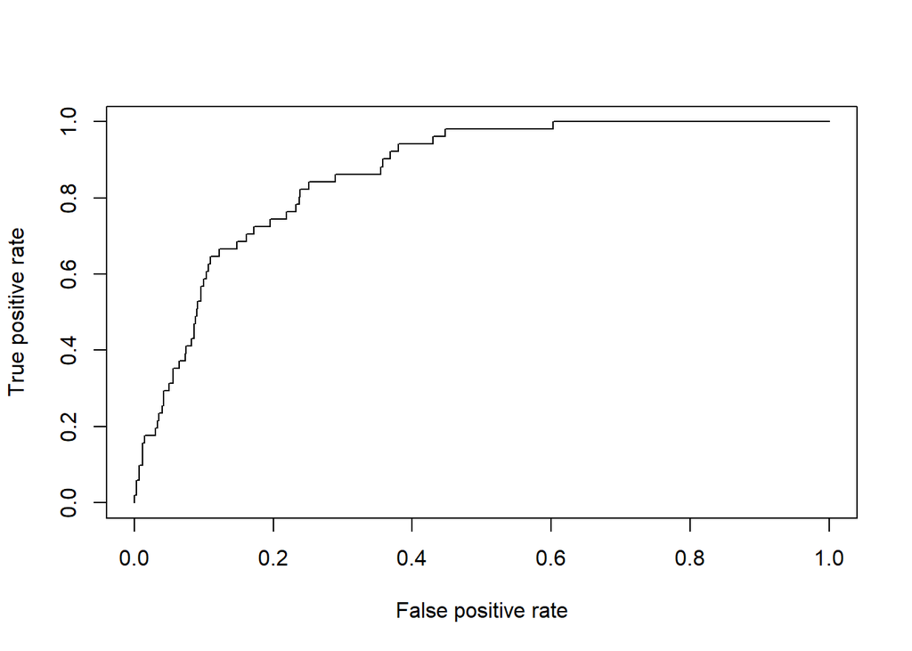

```r
library(ROCR)
# buat objek prediction
roc_pred <- prediction(predictions = df_roc_predNaive$prob,
                       labels = df_roc_predNaive$label)

# ROC curve
plot(performance(prediction.obj = roc_pred,
            measure = "tpr",
            x.measure = "fpr"))
```

Dengan membentuk L terbalik maka dapat disimpulkan bahwa model kita lumayan baik dalam memprediksi apakah pasien tersebut mengalami stroke atau tidak.

```r
# nilai AUC
votes_auc <- performance(prediction.obj = roc_pred,
                         measure = "auc")

str(votes_auc)
```

```
## Formal class 'performance' [package "ROCR"] with 6 slots
##   ..@ x.name      : chr "None"
##   ..@ y.name      : chr "Area under the ROC curve"
##   ..@ alpha.name  : chr "none"
##   ..@ x.values    : list()
##   ..@ y.values    :List of 1
##   .. ..$ : num 0.863
##   ..@ alpha.values: list()
```

```r
votes_auc@y.values
```

```
## [[1]]
## [1] 0.8626285
```

## Decision Tree

Tujuan Decision Tree yaitu memisahkan data menjadi kelompok-kelompok kecil berdasarkan variable tertentu sehingga dihasilkan **data yang homogen** atau homogenitas tinggi. Ukuran homogenitas dapat dikuantifikasi dengan nilai **entropy**.

Visualisasi Decision Tree:

```r
library(partykit)
model_stroke <- ctree(formula = stroke~.,
                    data = stroke_trainDown)
```

Struktur Pohon :

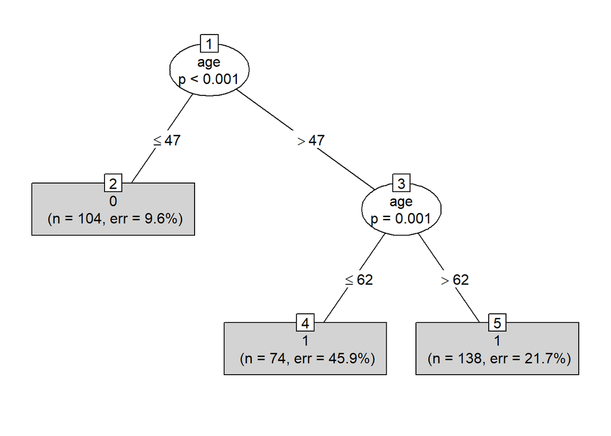

```r
# print struktur pohon
plot(model_stroke, type = "simple")
```

```r
# prediksi kelas di data test
predStroke_Tree <- predict(object = model_stroke,
                          newdata = stroke_test,
                          type = "response")

# confusion matrix data test
confusionMatrix(predStroke_Tree, reference = stroke_test$stroke, positive = "1")
```

```
## Confusion Matrix and Statistics
##
##           Reference
## Prediction   0   1
##          0 677   3
##          1 500  48
##
##                Accuracy : 0.5904
##                  95% CI : (0.5623, 0.6181)
##     No Information Rate : 0.9585
##     P-Value [Acc > NIR] : 1
##
##                   Kappa : 0.0912
##
##  Mcnemar's Test P-Value : <0.0000000000000002
##
##             Sensitivity : 0.94118
##             Specificity : 0.57519
##          Pos Pred Value : 0.08759
##          Neg Pred Value : 0.99559
##              Prevalence : 0.04153
##          Detection Rate : 0.03909
##    Detection Prevalence : 0.44625
##       Balanced Accuracy : 0.75818
##
##        'Positive' Class : 1
##
```

# Kesimpulan